# Lines

## Learning objectives

- understand independent and dependent variables
- understand the shape of lines
- understand how we might fit a line to data

## Variables

We are interested in **bivariate** data - one **independent** variable - AKA a predictor/explanatory variable - which we call x by convention - one **dependent** variable - AKA response/outcome variable - we call y by convention##

## Lines

The general form of a line is

```
y = a * x + b
```

a: this is the gradient (i.e. “how many units of y do we travel if we travel one x unit to the right?) Gradient also known as slope

e.g. a = 6 means we go 6 units upward along y for every 1 unit rightward along x e.g. a = -4 means we go 4 units downward along y for every 1 unit rightward along x

b: is called the **intercept** (i.e. “where does the line cross the y-axis?”)

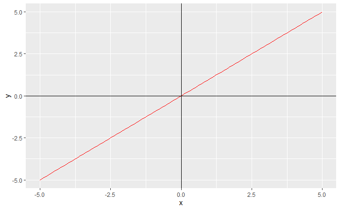

```r
library(tidyverse)

# let's write our own line function

line <- function(x, a, b){
    return (a * x + b)
}

# set up x vector and use line() to compute y values

data <- tibble(
    x = seq(-5, 5, 0.1),
    y = line(x, a = 1, b = 0)
)

data %>%
    ggplot(aes(x, y)) +
    geom_line(col = "red") +
    geom_vline(xintercept = 0) +
    geom_hline(yintercept = 0)
```

## Fitting a line to data

Let’s go back to our sunny beach day example: - independent variable : temperature - dependent variable: ice cream sales

```
Can temperature predict ice cream sales?
```

Why do we want to fit a function to our data? 1) Data is complicated - if we can represent it with a single mathematical function, that makes it much easier to understand (e.g. 1 degree in temp increase relates to an increase of 5 in ice cream sales)

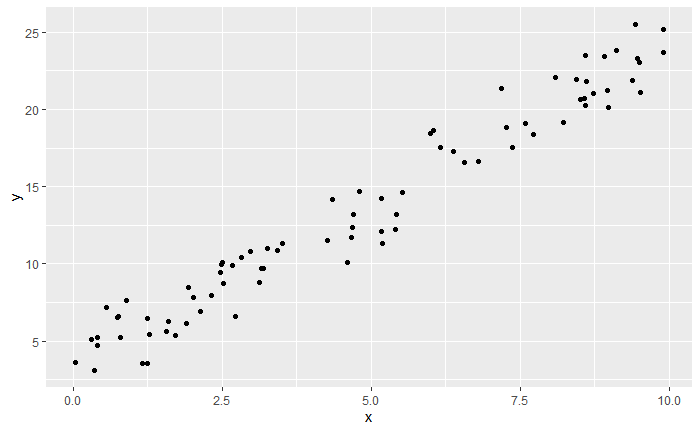

```r
noisy_line <- read_csv("data/noisy_line.csv")
noisy_line_plot <- noisy_line %>%
    ggplot(aes(x, y)) +
    geom_point()

noisy_line_plot
```

Now let’s calculate the centroid position (mean x, mean y) and add it to the plot:

```r
centroid <- noisy_line %>%
    summarise(
        x = mean(x),
        y = mean(y)
    )

centroid
```

| x | y |
| --- | --- |
| 4.806482 | 13.44237 |

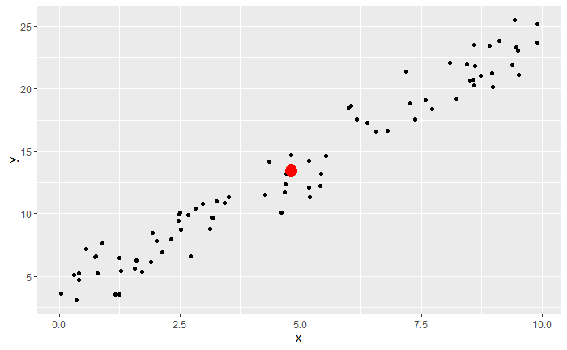

```r
noisy_line_plot <- noisy_line_plot +
    geom_point(aes(x = centroid$x, y = centroid$y), col = "red", size = 5)

noisy_line_plot
```

So our best fit line has to pass through the centroid. You can think of it as finding the answer to the question “which line passing through the red dot (centroid) lies ‘closest’ to all the data points?”

equation of a line is y = (a * x) + b we want to find the intercept b: b = y - (a * x)

Let’s do this manually:

```r
get_intercept <- function(shape, centroid_x, centroid_y){
    return(centroid_y - slope * centroid_x)
}
```

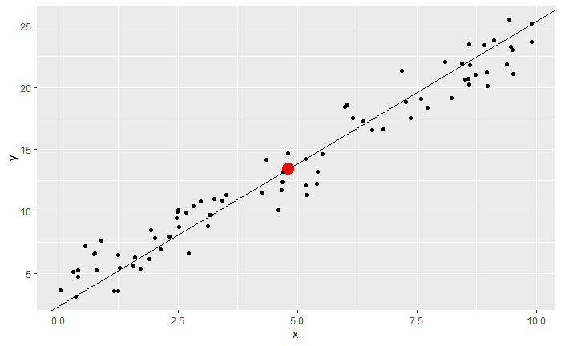

```r
slope = 2.3
noisy_line_plot +
    geom_abline(slope = slope, intercept = get_intercept(slope, centroid$x, centroid$y))
```

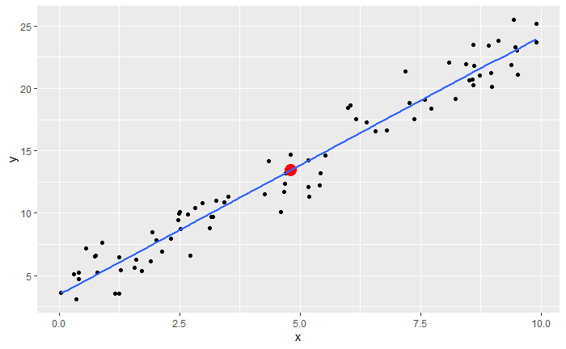

## The principle of parsimony

AKA Occam’s razor

In a general sense, it says that:

*Given two or more ‘explanations’ of comparable quality, the simplest explanation is the best one*

In terms of statistics, it tells us that: - fitting models should have minimal parameters (i.e. a straight line over a wiggly line) - experiments should have as few assumptions as possible - linear models should be tried prior to non-linear models

Remember, however: *Everything should be made as simple as possible, but not simpler*